# Rapport de groupe des UE Bases de données + Sciences des Données 2

Sara Fenina,

Ambinintsoa Rakoto,

Stéphanie Sbircéa,

26 mars 2026

# Introduction

Dans le cadre de ce projet, nous nous intéressons au système d’échange Wonder Trade du jeu vidéo Pokémon Sun and Moon, qui permet aux joueurs d’échanger des Pokémon de manière aléatoire avec d’autres joueurs à travers le monde. Ce système constitue un exemple intéressant d’interactions entre joueurs, où les décisions d’échange peuvent refléter des stratégies, des préférences ou encore une certaine gestion des ressources disponibles dans le jeu. En effet, chaque joueur dispose de Pokémon ayant des caractéristiques différentes, notamment en termes de puissance, de rareté ou de type, ce qui peut influencer leur choix de les conserver ou de les échanger.

Ainsi, on peut se demander si les échanges réalisés dans le Wonder Trade sont réellement aléatoires du point de vue de la qualité des Pokémon, ou s’ils révèlent des comportements spécifiques de la part des joueurs. Autrement dit, les joueurs ont-ils tendance à échanger des Pokémon moins performants ou moins rares, ou observe-t-on également la présence de Pokémon puissants et recherchés dans ce système ? Cette interrogation est centrale pour comprendre la logique des échanges et les stratégies adoptées par les joueurs. Nous formulons donc la problématique suivante: ## Les caractéristiques statistiques d’un Pokémon (puissance, rareté, type) influencent-elles sa probabilité d’être échangé dans le système Wonder Trade de Pokémon Sun and Moon?

Cette question présente un intérêt à la fois en analyse de données et en compréhension des comportements dans les environnements numériques. En effet, si les joueurs échangent majoritairement des Pokémon faibles ou communs, cela pourrait indiquer une logique d’optimisation individuelle. À l’inverse, la présence de Pokémon rares ou puissants dans les échanges pourrait révéler des comportements différents, comme la recherche d’aléatoire, la générosité ou des stratégies spécifiques. Ainsi, l’étude de cette problématique permet de mieux comprendre les dynamiques d’échange dans ce système et d’appliquer des outils statistiques pour analyser ces comportements.

#Rôles

Sarah Guilleminot : Étudiant n°XXXX, Resp. de la collecte des données.

Sara Fenina : Étudiant n°XXXX, Resp. du rapport.

## Quelques détails techniques

**R Markdown :** Pour créer ce rapport, on vous demande d’utiliser `R Markdown`, via le logiciel `RStudio`.

Pour vous aider, on vous fournit un fichier `.Rmd` qui contient la structure du projet et qui présente quelques exemples de la syntaxe à utiliser. Vous pouvez donc partir de ce fichier et le modifier à votre guise. (Nous suggérons que vous organisiez votre rapport en utilisant des chapitres mais, en fonction de votre projet, rien ne vous empêche d’adopter une structure différente.)

La «compilation» (*i.e.*, «Kniter») du `Rmd` permet de créer soit un fichier PDF, soit un fichier Word, soit un fichier HTML (le PDF étant celui pour lequel les choses se passent le mieux, et aussi le format attendu pour ce cours).

Le désavantage de travailler avec un `.Rmd` sous `RStudio` est que vous travaillez en local : il faudra donc bien faire attention de prendre en compte les modifications de chacun.

**Editeur collaboratif :** Lorsque votre rapport sera proche de sa version finale, i.e. lorsqu’il ne restera que du texte à modifier, vous pourrez utilier le logiciel Overleaf (https://overleaf.com) pour collaborer avec les autres membres de votre équipe directement sur la version de ce document (qui est un sous-produit créé quand vous cliquez sur Knit depuis RStudio).

| Les tables | sont | cool |
| --- | --- | --- |
| col 1 est | alignée à gauche | $1600 |
| col 2 est | centrée | $12 |
| col 3 est | alignée à droite | $1 |

```r
install.packages("knitr")
library(knitr)
# Créer un tableau simple avec kable
df <- data.frame(Nom = c("Alice", "Bob"), Age = c(25, 30))
kable(df, format = "latex") # Peut aussi être "html", "latex"
```

[output not shown]

# Base de données

## Descriptif des tables

[output not shown]

## Modèles MCD et MOD

[figure not shown]

  Relations.

Noter en passant qu’il est possible de créer des diagrammes en R Markdown au moyen du package `DiagrammeR` [] comme on peut le voir ci-dessous.

```r
# install.packages("webshot",dependencies = TRUE)
# library(webshot)
# webshot::install_phantomjs()
Sys.setenv(OPENSSL_CONF="/dev/null")
DiagrammeR::grViz("
digraph boxes_and_circles {

  # a 'graph' statement
  graph [overlap = true, fontsize = 10]

  # several 'node' statements
  node [shape = box,
        fontname = Helvetica]
  A; B; C; D; E; F

  node [shape = circle,
        fixedsize = true,
        width = 0.9] // sets as circles
  1; 2; 3; 4; 5; 6; 7; 8

  # several 'edge' statements
  A->1 B->2 B->3 B->4 C->A
  1->D E->A 2->4 1->5 1->F
  E->6 4->6 5->7 6->7 3->8
}
")
```

[interactive chart not shown]

## Requêtes réalisées

L’objectif est de varier le type de requêtes et de répondre à votre problématique initiale.

## Quelques détails techniques

On peut interagir avec une base de données directement depuis RMarkdown : i.e. requêter puis récupérer et afficher le résultat directement depuis le .Rmd. Un fichier connexionBDD.Rmd est fourni pour donner des exemples.

# Matériel et Méthodes

## Logiciels

R (ou Python) est le logiciel à privilégier pour la Science des Données. Pour assurer une reproductibilité maximale, vous devriez utiliser R Markdown (ou un Notebook Jupyter, et éventuellement un outil de gestion des versions tel que `Git`), par exemple via Google Colab ou RStudio dans les nuages. Évitez d’utiliser Word!

## Modélisation statistique

Il est également bon d’indiquer quelles sont les avantages et les limites de ces méthodes.

Vous pourrez consulter avec profit les Chapitre 11–13 du livre sur R :

http://biostatisticien.eu/springeR/livreR.pdf

# Analyse Exploratoire des Données

Toute étude impliquant des données doit **obligatoirement** inclure une analyse exploratoire préalable. Celle-ci permet de mieux comprendre l’information contenue dans les données.

Il faut produire de nombreux résumés graphiques (*e.g.*, histogrammes, nuages de points, boxplots, etc.) et numériques (*e.g.*, médiane, moyenne, variance, etc.). Ainsi, il faut faire une analyse descriptive uni- et bivariée systématique de toutes les variables du jeu de données. Puis, il faut uniquement conserver les plus pertinents (les autres pouvant être gardés en Annexe), c’est-à-dire ceux qui permettront de dégager des éléments de réponse pour la question de recherche envisagée. Chaque figure et tableau doit être commenté. Mais il ne faut pas extrapoler et dire des choses qui ne sont pas visibles dans ces graphiques ou tableaux. Pour chaque analyse, vous pourrez préciser le nombre d’individus/ d’unités statistiques concernés au total.

Vous pourrez consulter avec profit le Chapitre 9 du livre sur R :

http://biostatisticien.eu/springeR/livreR.pdf

## Utiliser R

Il est facile d’inclure des codes R dans votre rapport, qui seront exécutés à la volée (*i.e.*, lors de la traduction de votre fichier `Rmd` en fichier `PDF` ou `DOC`). Par exemple:

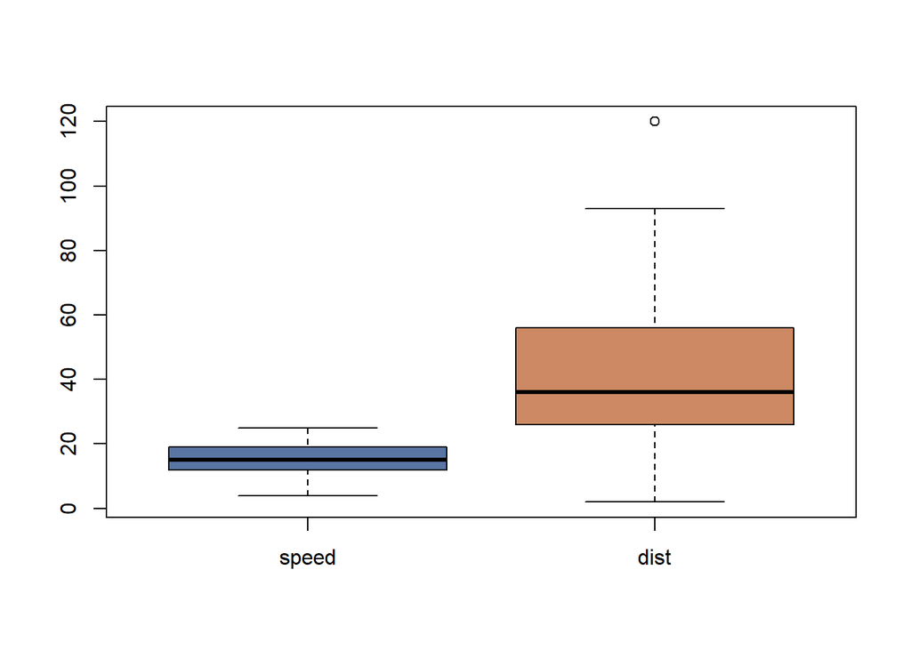

Deux boxplots.

```r
boxplot(cars, col = c("#5975a4", "#cc8963"))
```

```r
colMeans(cars)
```

```
## speed  dist
## 15.40 42.98
```

Les lignes de code ne doivent pas dépasser dans la marge de droite. Ainsi on pourrait remplacer le chunk ci-dessous:

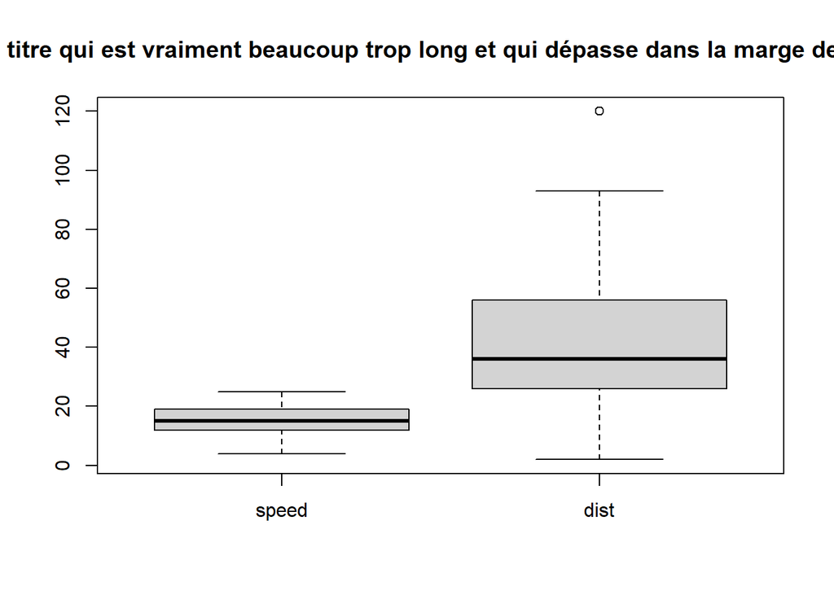

Pas super.

```r
boxplot(cars, main = "Un titre qui est vraiment beaucoup trop long et qui dépasse dans la marge de droite")
```

par celui-ci:

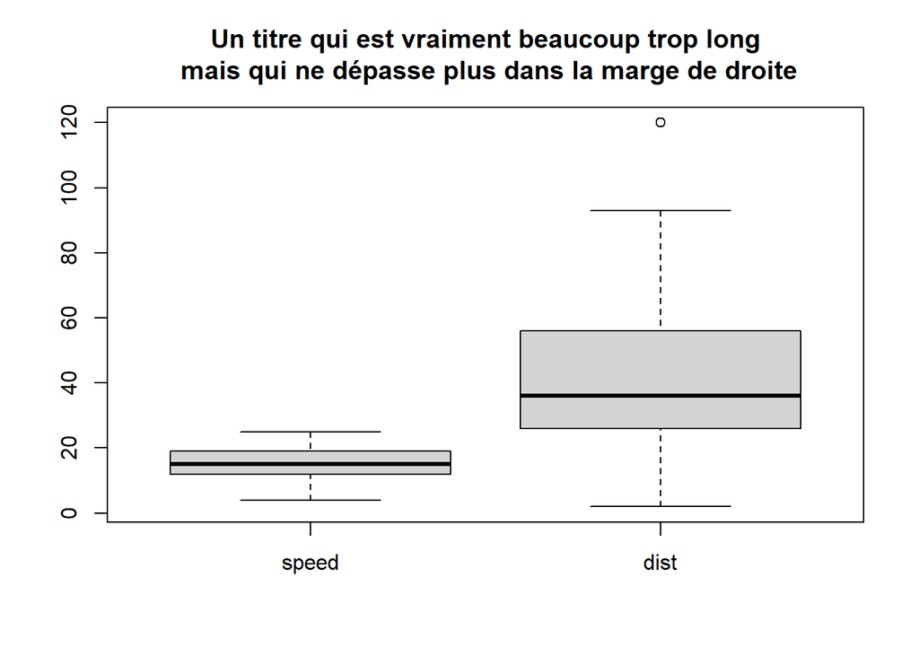

Déjà mieux.

```r
boxplot(cars,
        main = "Un titre qui est vraiment beaucoup trop long\n mais qui ne dépasse plus dans la marge de droite")
```

**Remarques** : Contrairement aux graphiques précédents, nous vous demandons, pour effectuer les graphiques, d’utiliser le package `ggplot2`. Voir https://juba.github.io/tidyverse/08-ggplot2.html pour une courte introduction.

# Inférence statistique et modélisation

Dans cette partie, vous pourrez utiliser les outils et méthodes vus au semestre précédent pour analyser les liens entre les variables.

Pour cela, vous pourrez utiliser les tests du $\chi^2$, test du coefficient de corrélation linéaire, test d’Anova, la droite de régression linéaire.

Vous pourrez également proposer des modèles pour faire du clustering (k-means, CAH), de la classification (K plus proches voisins par exemple) comme vu en Science des données 1.

Si on souhaite expliquer les variations d’une variables réponse $Y$ en fonction d’un certain nombre de prédicteurs $x_1,\ldots,x_p$, on peut utiliser un modèle de régression linéaire simple ($p=1$) ou multiple ($p>1$)

Vous pourrez toujours consulter avec profit les Chapitre 11–13 du livre sur R :

http://biostatisticien.eu/springeR/livreR.pdf

Ces chapitres détaillent l’utilisation de certains tests et modèles sous `R`.

# Discussion

# Conclusion et perspectives

On attend de vous deux types de perspectives : des perspectives à court terme pour améliorer rapidement votre approche et des perspectives à plus long terme qu’elles soient liées à la science des données ou au domaine métier pour lequel vous avez travaillé.

Lister également les difficultés rencontrées dans la partie BD (e.g., taille de la base, manque de données, …) et dans la partie statistique.

# Annexes

Il faut utiliser les annexes de façon judicieuse. C’est ici que l’on place des résultats trop volumineux pour apparaître dans le corps du rapport. Ou bien des résultats (e.g., graphiques) moins intéressants que les autres. Cela permet de limiter le nombre de pages du coeur du rapport, et d’ajouter des détails dans cette partie pour le lecteur désireux d’en savoir plus.

## **Tables**

Si vous avez des tableaux supplémentaires, vous pouvez les ajouter ici.

1. Table Markdown

une légende au-dessus du tableau.

| Les tables | sont | cool |
| --- | --- | --- |
| col 1 est | alignée à gauche | $1600 |
| col 2 est | centrée | $12 |
| col 3 est | alignée à droite | $1 |

Aligner les nombres de la troisième colonne sur la droite permet d’afficher les unités au-dessus des unités, les dizaines au-dessus des dizaines, etc. Il faut toujours privilégier cette présentation.